# PSTAT174 Final Project: U.S. Real GDP Forecast

Ryan Yee

5/29/2023

Abstract:

In this time series project, the goal was to forecast U.S. real GDP using quarterly data from 2002 to 2023. The project aims to identify key trends and patterns in U.S. real GDP over this period. Various time series techniques such as ARIMA, SARIMA, and data transformation were applied to the historical U.S. real GDP data. The data were analyzed for trends, seasonality, and other patterns. The selected forecasting models were evaluated based on their accuracy and performance using the 12 data points from the test sample.

The key results of the project reveal the important trends and patterns in U.S. real GDP, such as long-term growth, business cycles, and seasonality. The forecasting models demonstrated their effectiveness in capturing and predicting these patterns. The project provides valuable insights into the future trajectory of U.S. real GDP and offers guidance for policymakers and decision-makers.

Introduction:

The objective of this time series project is to forecast U.S. real GDP using quarterly data from 2002 to 2023. Real GDP is a crucial indicator of economic performance and plays a significant role in informing policy decisions, assessing economic health, and guiding investment strategies. Understanding the trends, patterns, and future trajectory of U.S. real GDP is of great importance for policymakers, economists, and businesses alike.

The dataset used in this project consists of quarterly U.S. real GDP data spanning a period of 22 years. Real GDP represents the inflation-adjusted value of all final goods and services produced within the United States, providing a measure of the country’s economic output.

The primary problem addressed in this project is forecasting U.S. real GDP. The goal is to develop accurate and reliable models that can capture the underlying trends, seasonality, and other dynamics in the data and provide forecasts for future quarters. To achieve this, various time series techniques such as SARIMA (Seasonal Auto Regressive Integrated Moving Average), and data transformation.

The results of this project will provide insights into the historical behavior of U.S. real GDP and shed light on its future trajectory. The accuracy and performance of the forecasting models will be evaluated based on transformed data variances, ACFs and PACFs of residuals, and model diagnostics. Positive results will indicate the efficacy of the selected models in capturing and predicting the dynamics of U.S. real GDP. Negative results, if any, will also be discussed, offering insights into potential challenges or limitations of the forecasting process.

The data for this project was obtained from a reliable and reputable source, the U.S. Bureau of Economic Analysis (BEA) and the Federal Reserve Economic Data (FRED) database. The specific source will be acknowledged, ensuring transparency and credibility. The software used for data analysis, modeling, and forecasting include R and its specialized time series analysis packages like “astsa”, “tsdl”, “MASS”, “ggplot2”, “ggfortify”, “qpcR” and “forecast”.

Data Source Details:

Source: U.S. Bureau of Economic Analysis

Release: Gross Domestic Product

Units: Billions of Chained 2012 Dollars, Not Seasonally Adjusted

Frequency: Quarterly

BEA Account Code: ND000334

U.S. Bureau of Economic Analysis, Real Gross Domestic Product [ND000334Q], retrieved from FRED, Federal Reserve Bank of St. Louis; https://fred.stlouisfed.org/series/ND000334Q, May 30, 2023.

```r
gdp.csv <- read.table("ND000334Q.csv", sep = ",", header = FALSE, skip = 1, nrows = 85)
head(gdp.csv)
```

```
##           V1       V2
## 1 2002-01-01 3263.869
## 2 2002-04-01 3362.508
## 3 2002-07-01 3401.820
## 4 2002-10-01 3460.159
## 5 2003-01-01 3340.163
## 6 2003-04-01 3429.079
```

```r
tail(gdp.csv)
```

```
##            V1       V2
## 80 2021-10-01 5110.951
## 81 2022-01-01 4855.857
## 82 2022-04-01 4985.795
## 83 2022-07-01 5018.093
## 84 2022-10-01 5157.178
## 85 2023-01-01 4949.655
```

DISCLAIMER: The following data set is not Gaussian distributed due to volatility during the Great Recession (December 2007 – June 2009) and the Pandemic (April 2020).

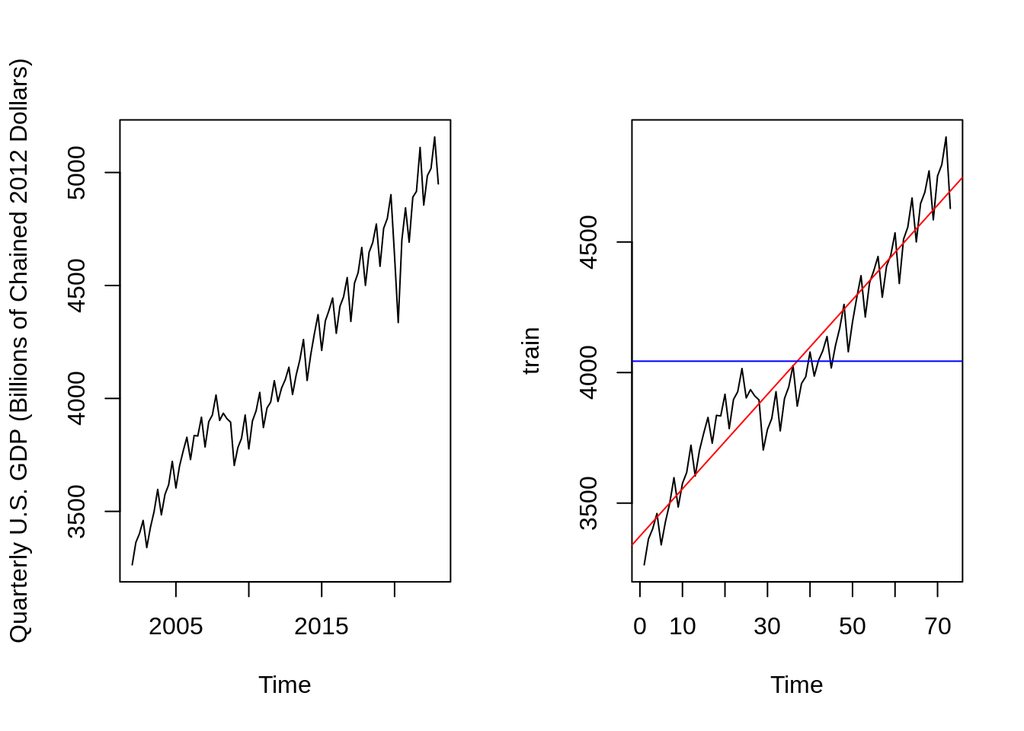

```r
gdp <- ts(gdp.csv[, 2], start = c(2002, 1), frequency = 4)
train <- gdp[1:73]
test <- gdp[74:85]
par(mfrow = c(1, 2))
ts.plot(gdp, ylab = "Quarterly U.S. GDP (Billions of Chained 2012 Dollars)")
plot.ts(train)

fit <- lm(train ~ as.numeric(1:length(train)))
abline(fit, col = "red")
abline(h = mean(train), col = "blue")
```

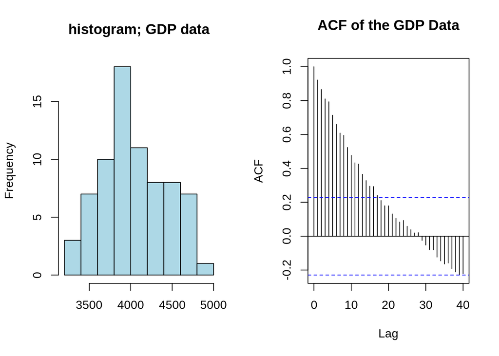

```r
hist(train, col = "light blue", xlab = "", main = "histogram; GDP data")
acf(train, lag.max = 40, main = "ACF of the GDP Data")
```

Histogram appear to be symmetric or bell-shaped (However, it is not Gaussian). One might argue it is a little bit skewed right. ACF remains large.

Compare transformations

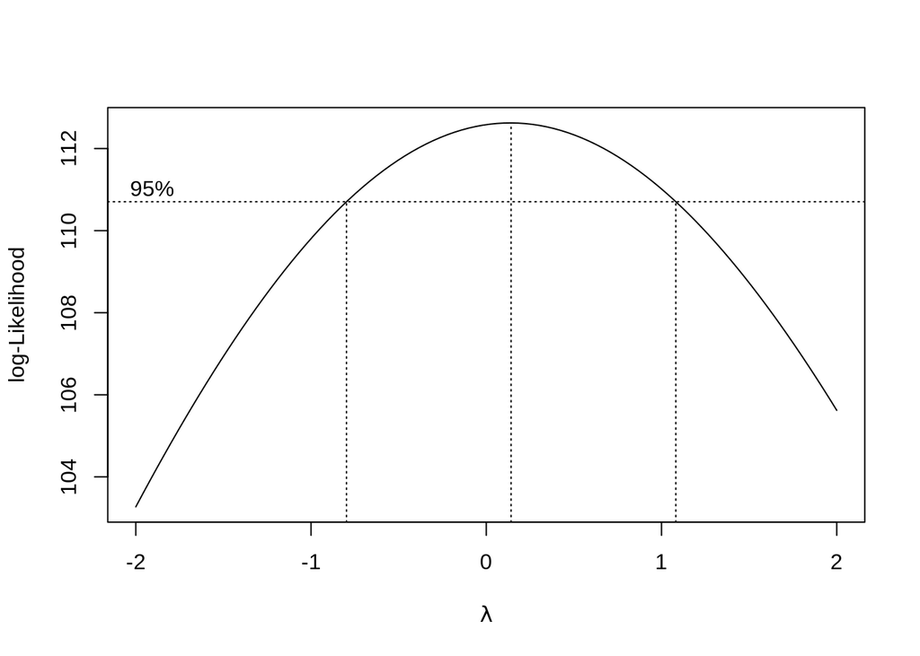

```r
bcTransform <- boxcox(train ~ as.numeric(1:length(train)))
```

```r
bcTransform$x[which(bcTransform$y == max(bcTransform$y))]
```

```
## [1] 0.1414141
```

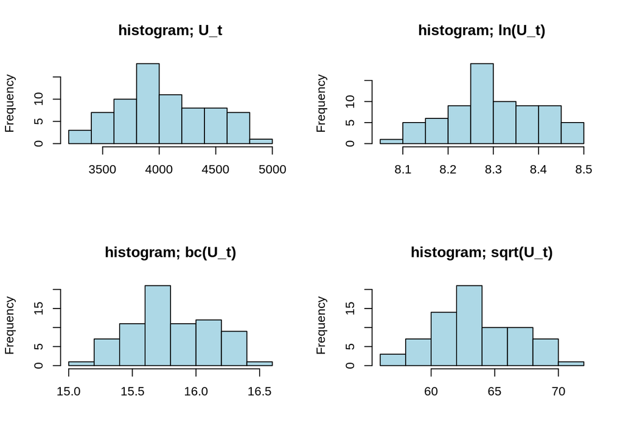

```r
lambda <- bcTransform$x[which(bcTransform$y == max(bcTransform$y))]
train.bc <- (1 / lambda) * (train^lambda - 1)
test.bc <- (1 / lambda) * (test^lambda - 1)
train.log <- log(train)
train.sqrt <- sqrt(train)

op <- par(mfrow = c(2, 2))
hist(train, col = "light blue", xlab = "", main = "histogram; U_t")
hist(train.log, col = "light blue", xlab = "", main = "histogram; ln(U_t)")
hist(train.bc, col = "light blue", xlab = "", main = "histogram; bc(U_t)")
hist(train.sqrt, col = "light blue", xlab = "", main = "histogram; sqrt(U_t)")
```

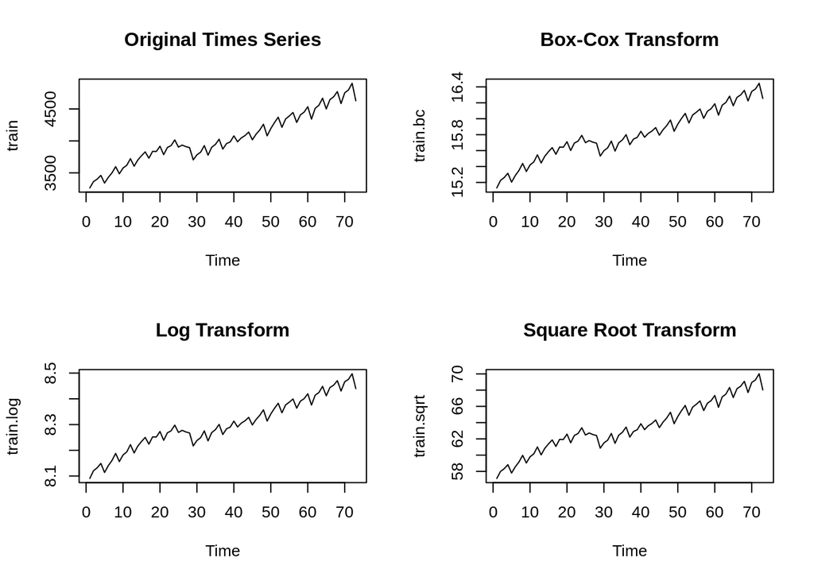

```r
# Compare transforms
op <- par(mfrow = c(2, 2))
ts.plot(train, main = "Original Times Series")
ts.plot(train.bc, main = "Box-Cox Transform")
ts.plot(train.log, main = "Log Transform")
ts.plot(train.sqrt, main = "Square Root Transform")
```

There isn’t much difference between transformations. One might argue that a transformation is unnecessary. Choose log(U_t) because it is more symmetric and seems to have more even variance.

Decomposition of $ln(U_t)$ shows seasonality and almost linear trend

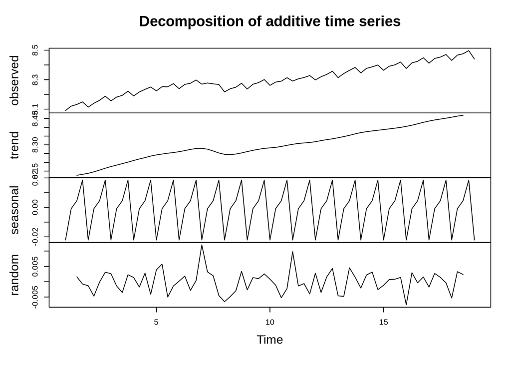

```r
y <- ts(as.ts(train.log), frequency = 4)
decomp <- decompose(y)
plot(decomp)
```

```r
var(train.log)
```

```
## [1] 0.009664501
```

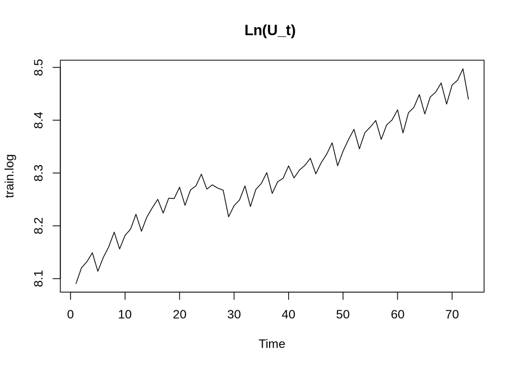

```r
plot.ts(train.log, main = "Ln(U_t) ")
```

```r
train.log_4 <- diff(train.log, lag = 4)
plot.ts(train.log_4, main = "Ln(U_t) differenced at lag 4")
var(train.log_4)
```

```
## [1] 0.0002872528
```

```r
fit <- lm(train.log_4 ~ as.numeric(1:length(train.log_4)))
abline(fit, col = "red")
mean(train.log_4)
```

```
## [1] 0.02010507
```

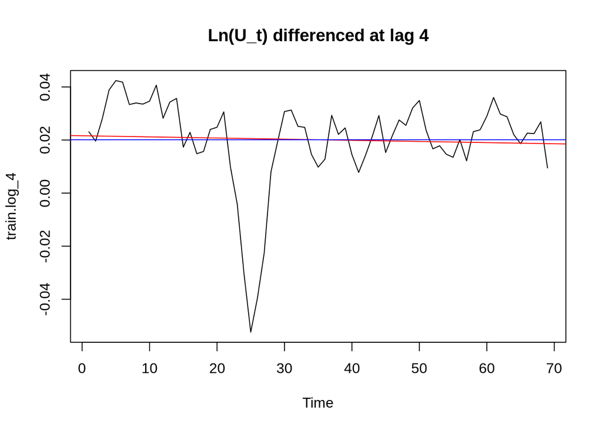

```r
abline(h = mean(train.log_4), col = "blue")
```

```r
train.log_4_1 <- diff(train.log_4, lag = 1)
plot.ts(train.log_4_1, main = "Ln(U_t) differenced at lags 4 and then 1")
var(train.log_4_1)
```

```
## [1] 9.788039e-05
```

```r
fit <- lm(train.log_4_1 ~ as.numeric(1:length(train.log_4_1)))
abline(fit, col = "red")
mean(train.log_4_1)
```

```
## [1] -0.0002004654
```

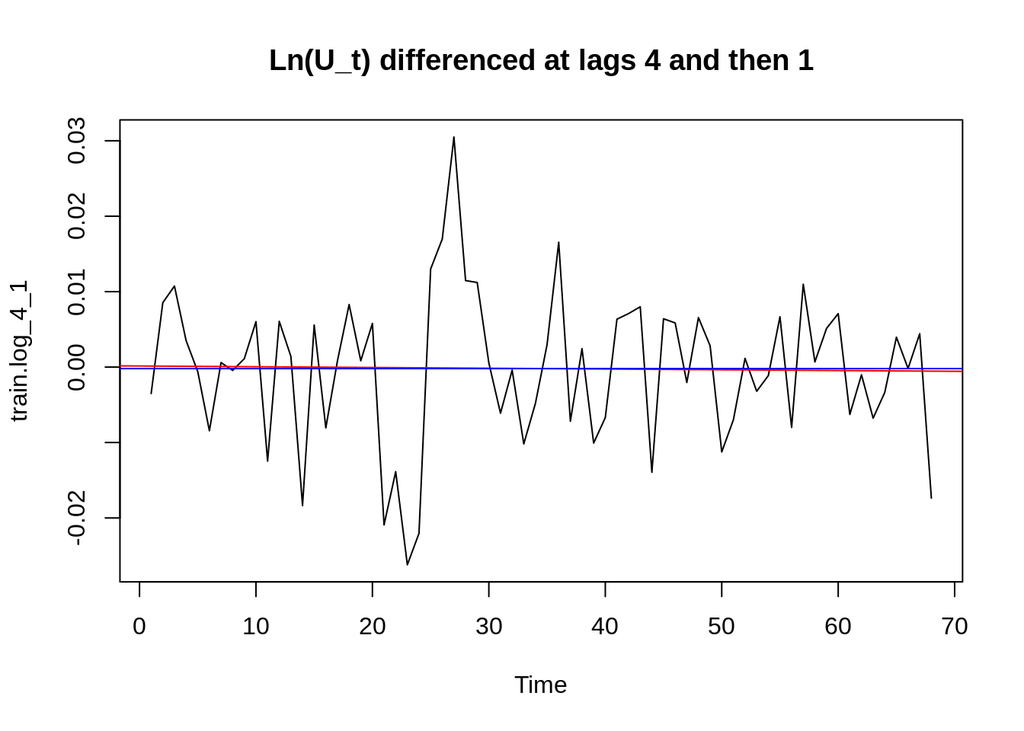

```r
abline(h = mean(train.log_4_1), col = "blue")
```

Plot of $ln(U_t)$

• Seasonality

• Trend

• Variance: 0.009665

Plot of $ln(U_t)$ differenced at lag 4

• Seasonality no longer apparent

• Variance: 0.0002873 – lower!

• Trend is still here

Plot of $ln(U_t)$ differenced at lags 4 and then 1

• No Seasonality

• Variance: 9.788e-05 – even lower!

• No trend

• Data looks stationary, but check ACFs

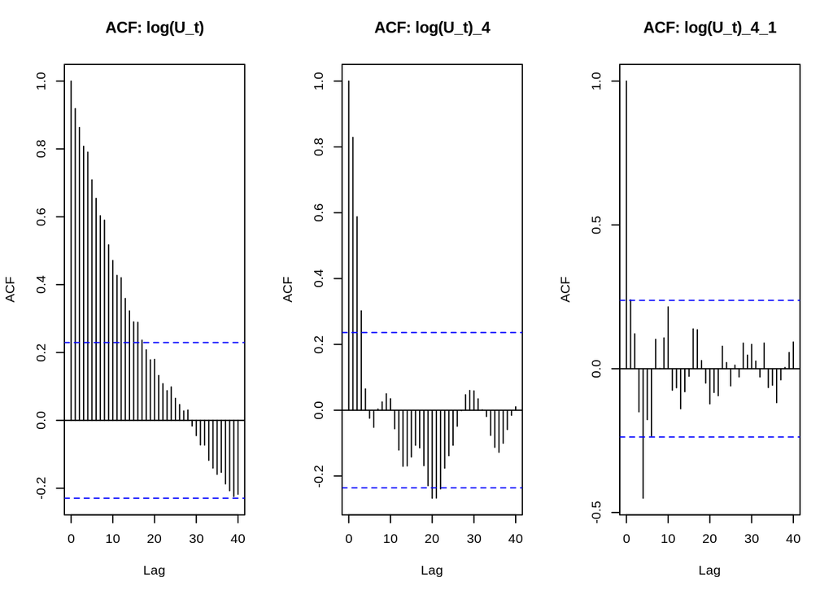

```r
par(mfrow = c(1, 3))
acf(train.log, lag.max = 40, main = "ACF: log(U_t)")
acf(train.log_4, lag.max = 40, main = "ACF: log(U_t)_4")
acf(train.log_4_1, lag.max = 40, main = "ACF: log(U_t)_4_1")
```

Plot of ACF of $ln(U_t)$

• Slows decay indicated non-stationarity

• One sees seasonality

Plot of ACF of $ln(U_t)$ differenced at lag 4

• Seasonality no longer apparent

• ACF decays slowly indicating non-stationarity

Plot of ACF of $ln(U_t)$ differenced at lags 4 & 1

• ACF decay corresponds to a stationary process Conclude: Work with data $ln(U_t)$ differenced at lags 4 & 1, $U_t$ = the first 73 observations of the original data.

Histogram of $\nabla1 \nabla 4 \space ln(U_t)$ looks symmetric and almost Gaussian.

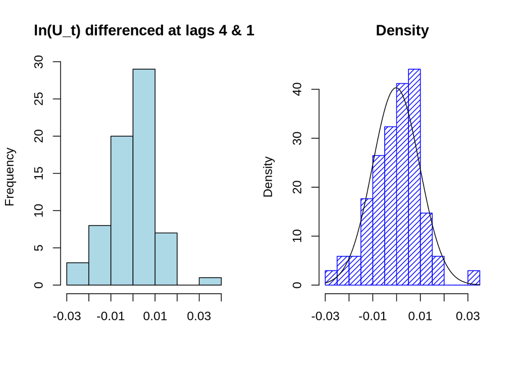

```r
par(mfrow = c(1, 2))
hist(train.log_4_1, col = "light blue", xlab = "", main = "ln(U_t) differenced at lags 4 & 1")
hist(train.log_4_1, density = 20, breaks = 20, col = "blue", xlab = "", main = "Density", prob = TRUE)
m <- mean(train.log_4_1)
std <- sqrt(var(train.log_4_1))
curve(dnorm(x, m, std), add = TRUE)
```

ACF and PACF of train.log_4_1 = $\nabla1 \nabla 4 \space ln(U_t)$,

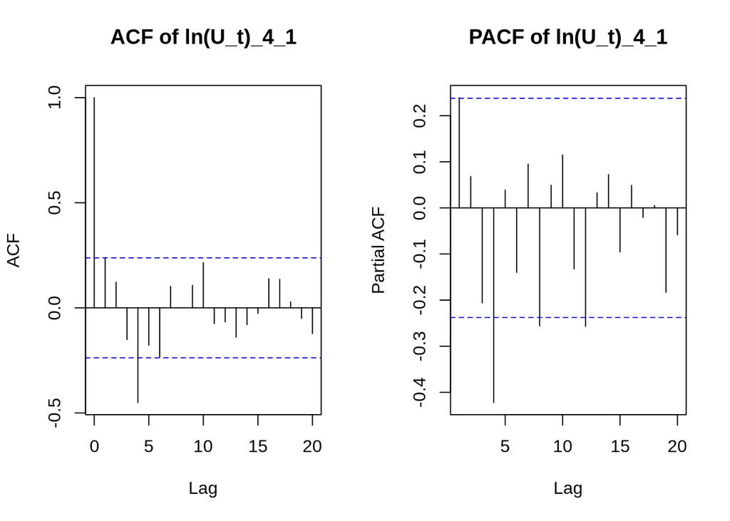

```r
par(mfrow = c(1, 2))
acf(train.log_4_1, lag.max = 20, main = "ACF of ln(U_t)_4_1")
pacf(train.log_4_1, lag.max = 20, main = "PACF of ln(U_t)_4_1")
```

Determine possible candidate models SARIMA$(p, d, q) \times (P, D, Q)_s$ for the series $ln(U_t)$.

Modeling the seasonal part (P, D, Q): For this part, focus on the seasonal lags h = 1s, 2s, etc.

• We applied one seasonal differencing so D = 1 at lag s = 4.

• The ACF shows a strong peak at h = 4s.

A good choice for the SMA part could be Q = 0, Q = 1

• The PACF shows a peak at h = 4s, 8s and 12s. A good choice for the SAR part could be P = 0, P = 1, P = 3.

Modeling the non-seasonal part (p , d, q): In this case focus on the within season lags, h = 1,. . . ,11.

• We applied one differencing to remove the trend: d = 1

• The ACF seems to be tailing off. Or perhaps cuts off at lag 4.

A good choice for the MA part could be q = 0, 1.

• The PACF cuts off at lag h=1 or 4.

A good choice for the AR part could be p = 0, 1.

As an illustration we fit the following model:

SARIMA (p = 1, d = 1, q = 1) × (P = 1, D = 1, Q = 1)s=4

SARIMA (p = 0, d = 1, q = 1) × (P = 1, D = 1, Q = 1)s=4

SARIMA (p = 0, d = 1, q = 0) × (P = 0, D = 1, Q = 1)s=4

SARIMA (p = 1, d = 1, q = 0) × (P = 0, D = 1, Q = 1)s=4

Evaluate candidate models by comparing their AICc.

```r
arima(train.log, order = c(4, 1, 4), seasonal = list(order = c(4, 1, 4), period = 4), method = "ML")
```

```
##
## Call:
## arima(x = train.log, order = c(4, 1, 4), seasonal = list(order = c(4, 1, 4),
##     period = 4), method = "ML")
##
## Coefficients:
```

```
##           ar1     ar2     ar3      ar4     ma1      ma2      ma3     ma4
##       -0.1864  0.5091  0.0887  -0.8158  0.4534  -0.3167  -0.2387  0.4697
## s.e.      NaN  0.1544  0.1215   0.0829     NaN      NaN   0.2366     NaN
##          sar1     sar2    sar3  sar4    sma1    sma2     sma3    sma4
##       -0.4179  -0.2166  0.3249  0.09  0.0358  -0.342  -0.7007  0.2117
## s.e.      NaN      NaN     NaN   NaN     NaN     NaN   0.1359     NaN
##
## sigma^2 estimated as 4.667e-05:  log likelihood = 237.54,  aic = -441.08
```

```r
AICc(arima(train.log, order = c(4, 1, 4), seasonal = list(order = c(4, 1, 4), period = 4), method = "ML"))
```

```
## [1] -431.3686
```

```r
arima(train.log, order = c(1, 1, 1), seasonal = list(order = c(1, 1, 1), period = 4), method = "ML")
```

```
##
## Call:
## arima(x = train.log, order = c(1, 1, 1), seasonal = list(order = c(1, 1, 1),
##     period = 4), method = "ML")
##
## Coefficients:
##          ar1      ma1    sar1     sma1
##       0.4739  -0.2655  0.0334  -0.8102
## s.e.  0.3534   0.3747  0.1762   0.1477
##
## sigma^2 estimated as 5.746e-05:  log likelihood = 233.48,  aic = -456.96
```

```r
AICc(arima(train.log, order = c(1, 1, 1), seasonal = list(order = c(1, 1, 1), period = 4), method = "ML"))
```

```
## [1] -456.3734
```

```r
arima(train.log, order = c(1, 1, 1), seasonal = list(order = c(1, 1, 1), period = 4), fixed = c(NA, 0, 0, NA), method = "ML")
```

```
##
## Call:
## arima(x = train.log, order = c(1, 1, 1), seasonal = list(order = c(1, 1, 1),
##     period = 4), fixed = c(NA, 0, 0, NA), method = "ML")
##
## Coefficients:
##          ar1  ma1  sar1     sma1
##       0.2132    0     0  -0.7857
## s.e.  0.1246    0     0   0.1197
##
## sigma^2 estimated as 5.808e-05:  log likelihood = 233.2,  aic = -460.39
```

```r
AICc(arima(train.log, order = c(1, 1, 1), seasonal = list(order = c(1, 1, 1), period = 4), fixed = c(NA, 0, 0, NA), method = "ML"))
```

```
## [1] -459.8038
```

```r
arima(train.log, order = c(1, 1, 0), seasonal = list(order = c(0, 1, 1), period = 4), method = "ML")
```

```
##
## Call:
## arima(x = train.log, order = c(1, 1, 0), seasonal = list(order = c(0, 1, 1),
##     period = 4), method = "ML")
##
## Coefficients:
##          ar1     sma1
##       0.2132  -0.7857
## s.e.  0.1246   0.1197
##
## sigma^2 estimated as 5.808e-05:  log likelihood = 233.2,  aic = -460.39
```

```r
AICc(arima(train.log, order = c(1, 1, 0), seasonal = list(order = c(0, 1, 1), period = 4), method = "ML"))
```

```
## [1] -460.2206
```

```r
arima(train.log, order = c(0, 1, 4), seasonal = list(order = c(1, 1, 1), period = 4), method = "ML")
```

```
##
## Call:
## arima(x = train.log, order = c(0, 1, 4), seasonal = list(order = c(1, 1, 1),
##     period = 4), method = "ML")
##
## Coefficients:
##          ma1     ma2      ma3     ma4     sar1     sma1
##       0.1984  0.2131  -0.0709  0.8025  -0.6712  -0.7937
## s.e.  0.0990  0.0906   0.1167  0.1242   0.1412   0.1261
##
## sigma^2 estimated as 5.009e-05:  log likelihood = 236.7,  aic = -459.39
```

```r
AICc(arima(train.log, order = c(0, 1, 4), seasonal = list(order = c(1, 1, 1), period = 4), method = "ML"))
```

```
## [1] -458.1217
```

```r
arima(train.log, order = c(0, 1, 4), seasonal = list(order = c(1, 1, 1), period = 4), fixed = c(NA, NA, 0, NA, NA, NA), method = "ML")
```

```
##
## Call:
## arima(x = train.log, order = c(0, 1, 4), seasonal = list(order = c(1, 1, 1),
##     period = 4), fixed = c(NA, NA, 0, NA, NA, NA), method = "ML")
##
## Coefficients:
##          ma1     ma2  ma3     ma4     sar1     sma1
##       0.1811  0.2353    0  0.8422  -0.6987  -0.7934
## s.e.  0.0826  0.0782    0  0.1030   0.1465   0.1237
##
## sigma^2 estimated as 5.1e-05:  log likelihood = 236.48,  aic = -460.96
```

```r
AICc(arima(train.log, order = c(0, 1, 4), seasonal = list(order = c(1, 1, 1), period = 4), method = "ML"))
```

```
## [1] -458.1217
```

```r
arima(train.log, order = c(1, 1, 1), seasonal = list(order = c(0, 1, 1), period = 4), method = "ML")
```

```
##
## Call:
## arima(x = train.log, order = c(1, 1, 1), seasonal = list(order = c(0, 1, 1),
##     period = 4), method = "ML")
##
## Coefficients:
##          ar1      ma1     sma1
##       0.4934  -0.2857  -0.7922
## s.e.  0.3434   0.3679   0.1163
##
## sigma^2 estimated as 5.759e-05:  log likelihood = 233.46,  aic = -458.93
```

```r
AICc(arima(train.log, order = c(1, 1, 1), seasonal = list(order = c(0, 1, 1), period = 4), method = "ML"))
```

```
## [1] -458.5779
```

```r
arima(train.log, order = c(0, 1, 0), seasonal = list(order = c(0, 1, 1), period = 4), method = "ML")
```

```
##
## Call:
## arima(x = train.log, order = c(0, 1, 0), seasonal = list(order = c(0, 1, 1),
##     period = 4), method = "ML")
##
## Coefficients:
##          sma1
##       -0.8046
## s.e.   0.1237
##
## sigma^2 estimated as 6.032e-05:  log likelihood = 231.77,  aic = -459.53
```

```r
AICc(arima(train.log, order = c(0, 1, 0), seasonal = list(order = c(0, 1, 1), period = 4), method = "ML"))
```

```
## [1] -459.4738
```

Conclusion:

Do not choose SARIMA (p = 4, d = 1, q = 4) × (P = 4, D = 1, Q = 4)s=4 because it has too many parameters and will not pass the model diagnostic.

model A: SARIMA (p = 1, d = 1, q = 0) × (P = 0, D = 1, Q = 1)s=4 has the lowest AICc of -460.2.

Model A: $(1 - 0.213_{(0.125)}B)Y_t = (1 - 0.786_{(0.120)}B^{4})Z_t$, where $\hat\sigma_z^2=0.0000581$.

Check invertibility of model B: SARIMA (p = 1, d = 1, q = 1) × (P = 1, D = 1, Q = 1)s=4

- ma = -0.265, sma = -0.810
- Model (B) is invertible because $|\theta_1|<1; |\Theta_1<1|$

Check invertibility of model A: SARIMA (p = 1, d = 1, q = 0) × (P = 0, D = 1, Q = 1)s=4

- it has no MA component so Model (A) is invertible.

Since model A has lower AICc and less parameters than model B.

Choose model A: SARIMA (p = 1, d = 1, q = 0) × (P = 0, D = 1, Q = 1)s=4 as our final model

[figure not shown]

```r
# Residual plots:
res <- fit.i$fit$residuals
mean(res)
```

```
## [1] -0.0006919207
```

```r
var(res)
```

```
## [1] 5.892286e-05
```

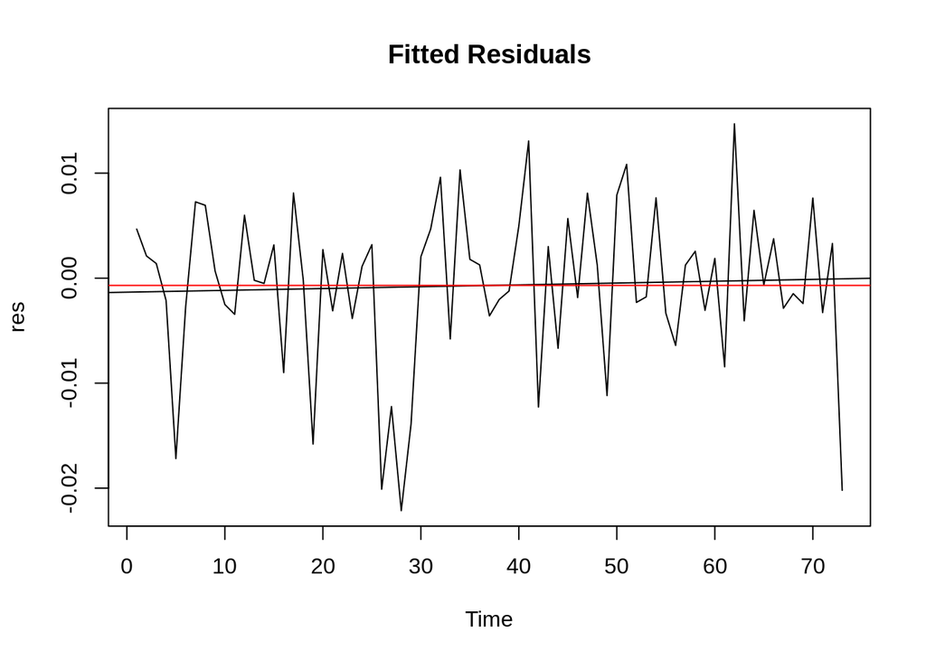

```r
# layout(matrix(c(1, 1, 2, 3), 2, 2, byrow=T))
par(mfrow = c(1, 1))
ts.plot(res, main = "Fitted Residuals")
t <- 1:length(res)
fit.res <- lm(res ~ t)
abline(fit.res)
abline(h = mean(res), col = "red")
```

```r
var(fit.res$residuals)
```

```
## [1] 5.878606e-05
```

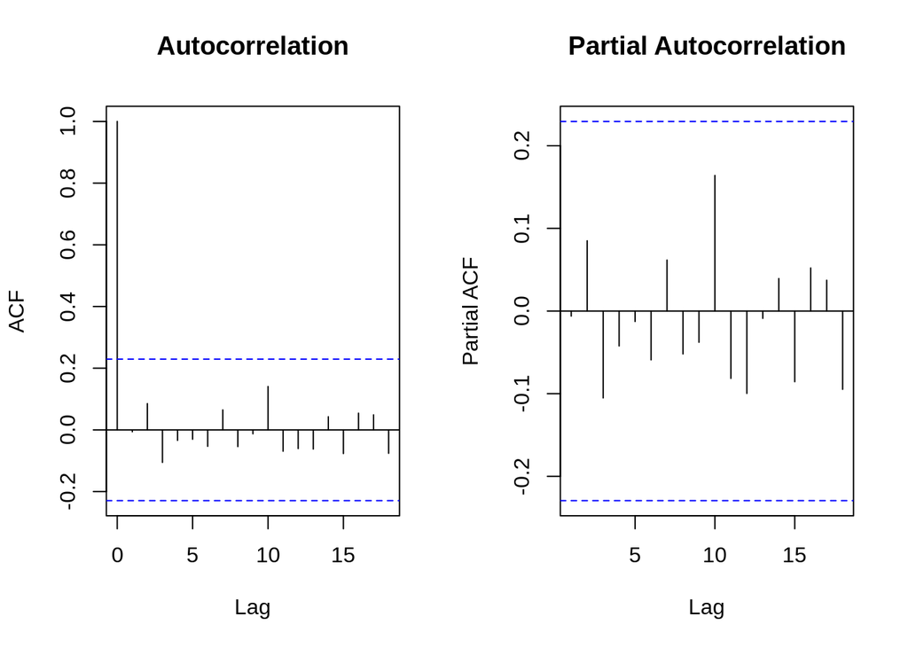

```r
# ACF and PACF:
par(mfrow = c(1, 2))
acf(res, main = "Autocorrelation")
pacf(res, main = "Partial Autocorrelation")
```

All acf and pacf of residuals are within confidence intervals and can be counted as zeros!

Model A passes all diagnostic except Shapiro-Wilk test (rejected at significance level 0.006).

```r
# Test for independence of residuals
Box.test(res, lag = 9, type = c("Box-Pierce"), fitdf = 2)
```

```
##
##  Box-Pierce test
##
## data:  res
## X-squared = 2.231, df = 7, p-value = 0.946
```

```r
Box.test(res, lag = 9, type = c("Ljung-Box"), fitdf = 2)
```

```
##
##  Box-Ljung test
##
## data:  res
## X-squared = 2.4344, df = 7, p-value = 0.932
```

```r
Box.test(res^2, lag = 9, type = c("Ljung-Box"), fitdf = 0)
```

```
##
##  Box-Ljung test
##
## data:  res^2
## X-squared = 7.647, df = 9, p-value = 0.5701
```

```r
# Test for normality of residuals
shapiro.test(res)
```

```
##
##  Shapiro-Wilk normality test
##
## data:  res
## W = 0.95066, p-value = 0.006283
```

```r
ar(res, aic = TRUE, order.max = NULL, method = c("yule-walker"))
```

```
##
## Call:
## ar(x = res, aic = TRUE, order.max = NULL, method = c("yule-walker"))
##
##
## Order selected 0  sigma^2 estimated as  5.892e-05
```

Residual appears not Gaussian as expected.

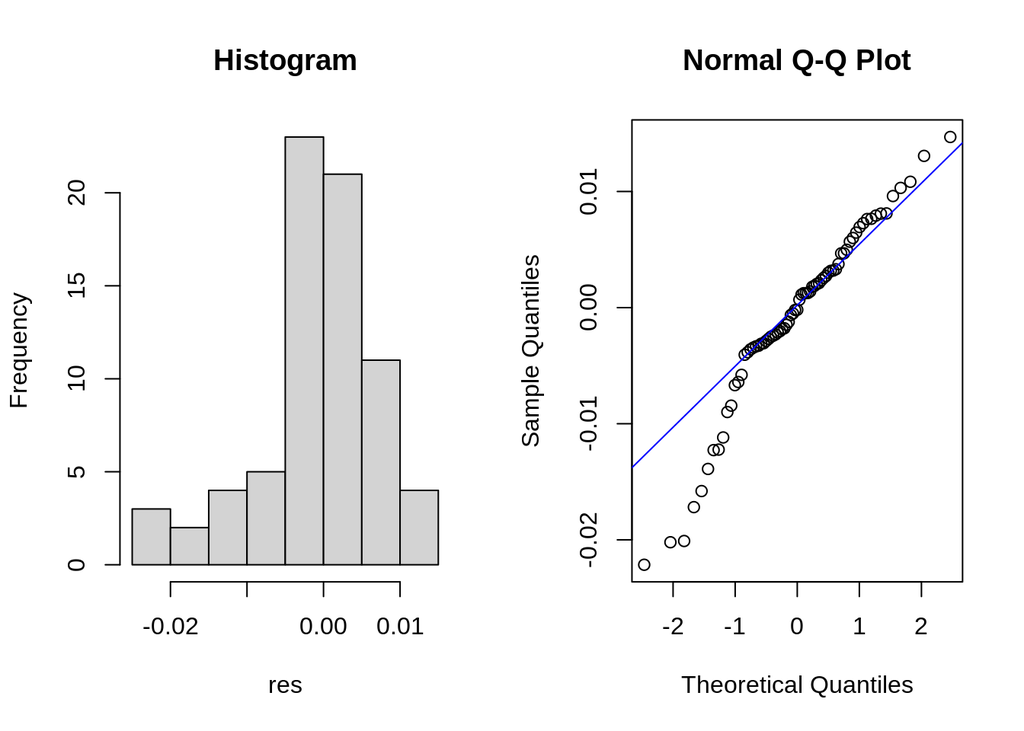

```r
# Histogram and QQ-plot:
par(mfrow = c(1, 2))
hist(res, main = "Histogram")
qqnorm(res)
qqline(res, col = "blue")
```

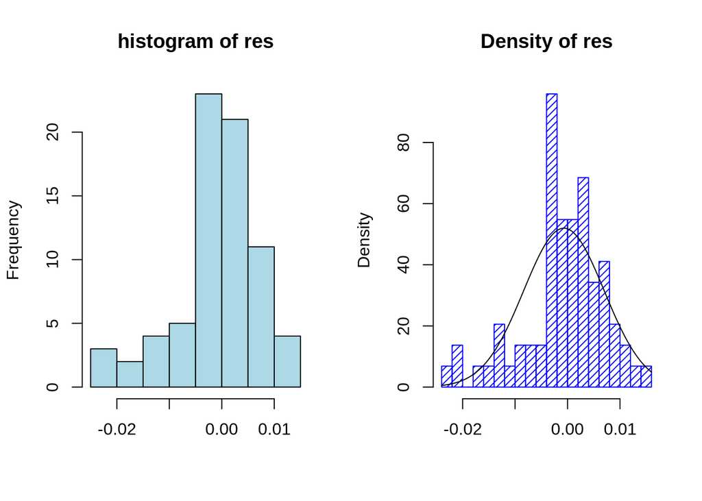

```r
par(mfrow = c(1, 2))
hist(res, col = "light blue", xlab = "", main = "histogram of res")
hist(res, density = 20, breaks = 20, col = "blue", xlab = "", main = "Density of res", prob = TRUE)
m <- mean(res)
# 0.001234
std <- sqrt(var(res))
curve(dnorm(x, m, std), add = TRUE)
```

```r
# Access the coefficients of the SARIMA model
coefficients <- coef(fit.i$fit)

# Print the coefficients
coefficients
```

```
##        ar1       sma1
##  0.2132024 -0.7857388
```

```r
# Access the variance
var <- fit.i$fit$sigma2
var
```

```
## [1] 5.807806e-05
```

Conclusions:

Model (A) passed all diagnostic checking except Shapiro-Wilk test and is the final model.

Model (B) and other models that have too many parameters will not be used because they are likely to fail the diagnostic test.

Final Model for the logarithm transform of original data: ln(U_t) follows SARIMA (1,1,0)(0,1,1) 4 model.

$\nabla1 \nabla 4 \space ln(U_t)=(1 - 0.213_{(0.125)}B)Y_t = (1 - 0.786_{(0.120)}B^{4})Z_t$, where $\hat\sigma_z^2=0.0000581$.

Compare and evaluate model forecasts using 12 test values from the true sample

SARIMA (p = 4, d = 1, q = 4) × (P = 4, D = 1, Q = 4)s=4

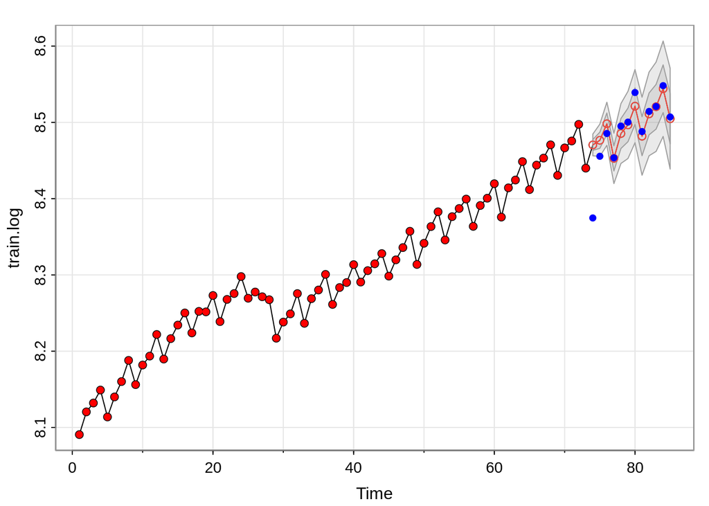

```r
x <- sarima.for(xdata = train.log, n.ahead = 12, p = 4, d = 1, q = 4, P = 4, D = 1, Q = 4, S = 4)
points(1:length(train), train.log, col = "red", pch = 19, cex = 0.8)
points(length(train) + 1:length(test), log(test), col = "blue", pch = 19, cex = 0.8)
```

SARIMA (p = 0, d = 1, q = 0) × (P = 0, D = 1, Q = 4)s=4

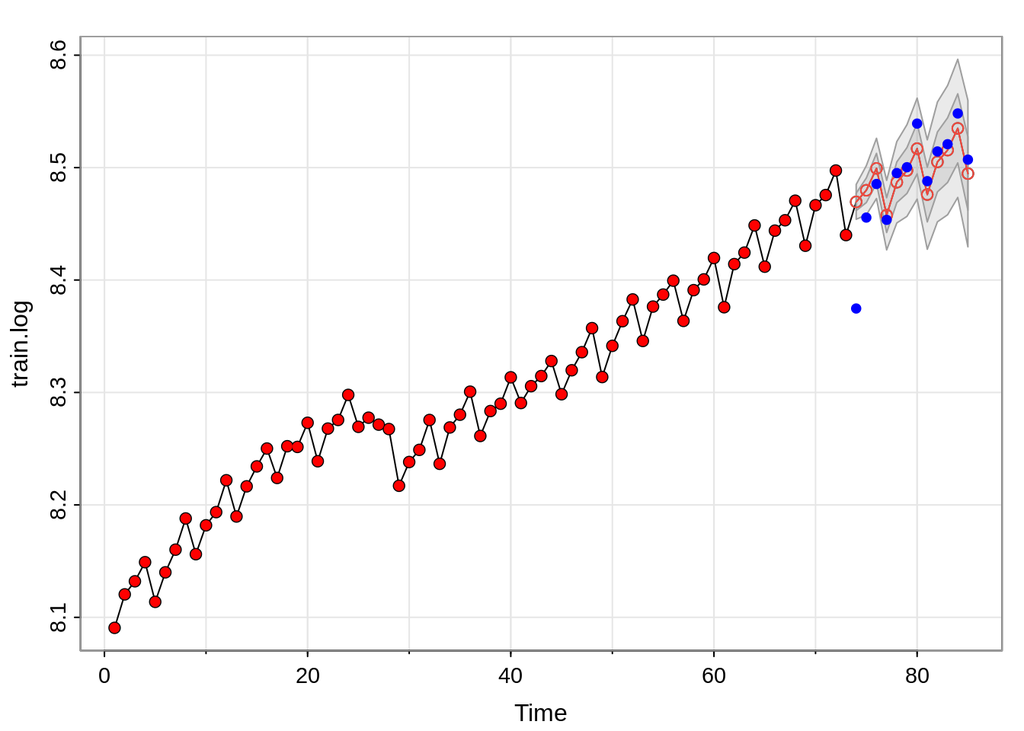

```r
x <- sarima.for(xdata = train.log, n.ahead = 12, p = 0, d = 1, q = 0, P = 0, D = 1, Q = 4, S = 4)
points(1:length(train), train.log, col = "red", pch = 19, cex = 0.8)
points(length(train) + 1:length(test), log(test), col = "blue", pch = 19, cex = 0.8)
```

SARIMA (p = 0, d = 1, q = 4) × (P = 1, D = 1, Q = 1)s=4

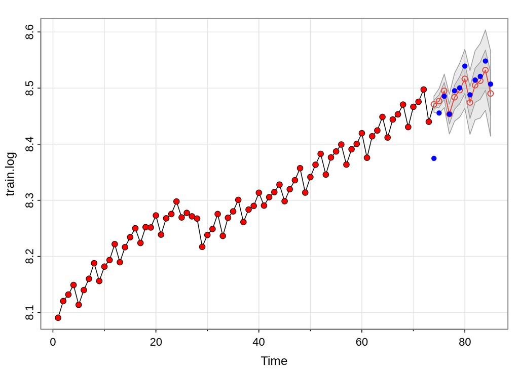

```r
x <- sarima.for(xdata = train.log, n.ahead = 12, p = 0, d = 1, q = 4, P = 1, D = 1, Q = 1, S = 4)
points(1:length(train), train.log, col = "red", pch = 19, cex = 0.8)
points(length(train) + 1:length(test), log(test), col = "blue", pch = 19, cex = 0.8)
```

SARIMA (p = 1, d = 1, q = 1) × (P = 1, D = 1, Q = 1)s=4

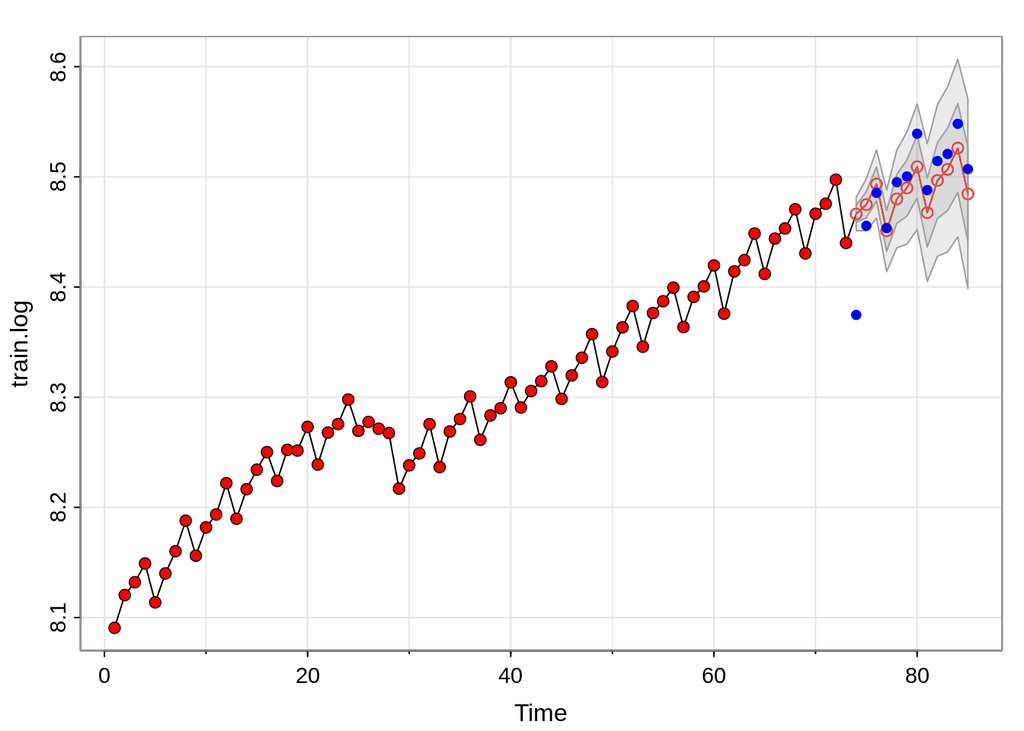

```r
x <- sarima.for(xdata = train.log, n.ahead = 12, p = 1, d = 1, q = 1, P = 1, D = 1, Q = 1, S = 4)
points(1:length(train), train.log, col = "red", pch = 19, cex = 0.8)
points(length(train) + 1:length(test), log(test), col = "blue", pch = 19, cex = 0.8)
```

SARIMA (p = 1, d = 1, q = 0) × (P = 0, D = 1, Q = 1)s=4

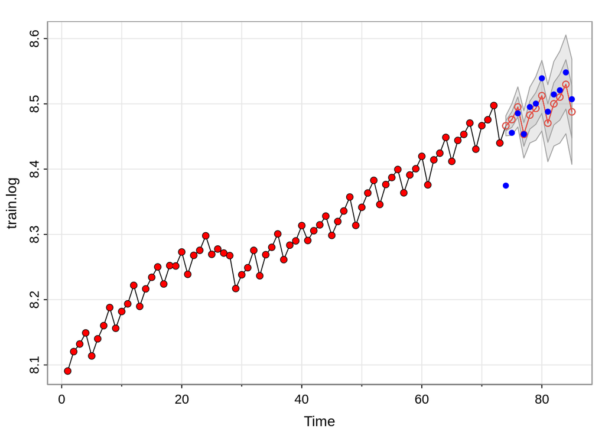

```r
x <- sarima.for(xdata = train.log, n.ahead = 12, p = 1, d = 1, q = 0, P = 0, D = 1, Q = 1, S = 4)
points(1:length(train), train.log, col = "red", pch = 19, cex = 0.8)
points(length(train) + 1:length(test), log(test), col = "blue", pch = 19, cex = 0.8)
```

We can see that all the above models presents fairly accurate forecasts. Suggesting that more than one model may be appropriate in forecasting U.S. Real GDP.

It is not clear which model best captures the trend and trajectory. This is reasonable since the original data is not Gaussian due to volatility during the Great Recession (December 2007 – June 2009) and the Pandemic (April 2020).

The non-Gaussian like behavior may cause the forecasting values to shift up and down depending on when the volatility occurred in historical data.

Forecast of transformed data using model A

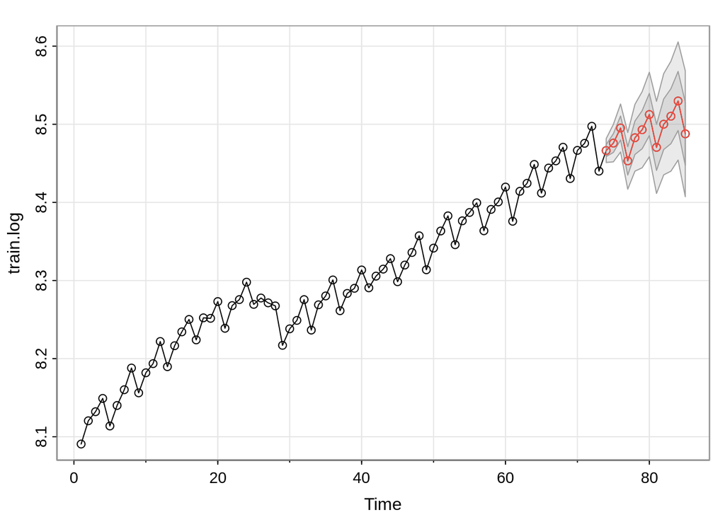

```r
pred.tr <- sarima.for(xdata = train.log, n.ahead = 12, p = 1, d = 1, q = 0, P = 0, D = 1, Q = 1, S = 4)
```

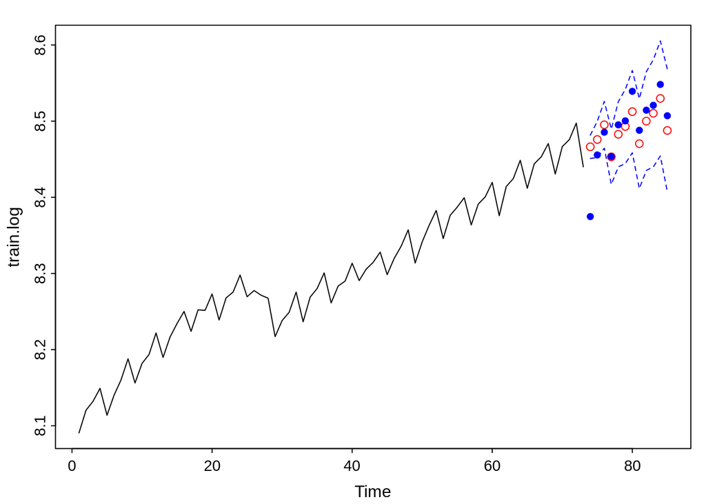

```r
U.tr <- pred.tr$pred + 2 * pred.tr$se
L.tr <- pred.tr$pred - 2 * pred.tr$se
ts.plot(train.log, xlim = c(1, length(train.log) + 12), ylim = c(min(train.log), max(U.tr)))
lines(U.tr, col = "blue", lty = "dashed")
lines(L.tr, col = "blue", lty = "dashed")
points((length(train.log) + 1):(length(train.log) + 12), pred.tr$pred, col = "red")
points(length(train) + 1:length(test), log(test), col = "blue", pch = 19, cex = 0.8)
```

Forecast of original data using model A

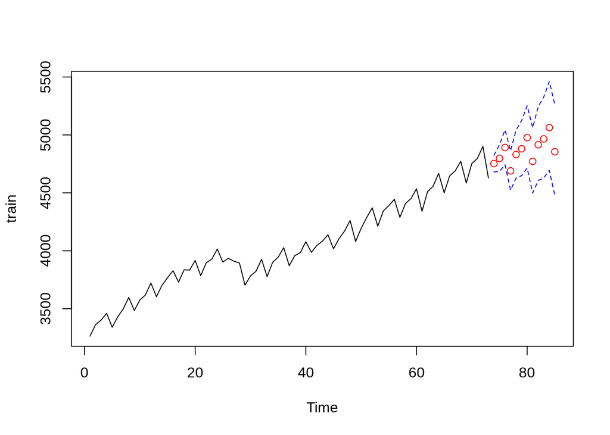

```r
pred.orig <- exp(pred.tr$pred)
U <- exp(U.tr)
L <- exp(L.tr)
ts.plot(train, xlim = c(1, length(train) + 12), ylim = c(min(train), max(U)))
lines(U, col = "blue", lty = "dashed")
lines(L, col = "blue", lty = "dashed")
points((length(train) + 1):(length(train) + 12), pred.orig, col = "red")
```

Forecasts - Black circles

Original data - Red line

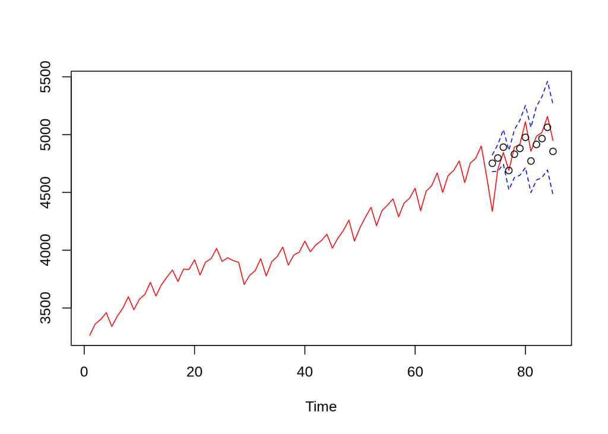

```r
ts.plot(gdp.csv, xlim = c(1, length(train) + 12), ylim = c(min(train), max(U)), col = "red")
lines(U, col = "blue", lty = "dashed")
lines(L, col = "blue", lty = "dashed")
points((length(train) + 1):(length(train) + 12), pred.orig, col = "black")
```

Zoomed Forecast of original Data using model A

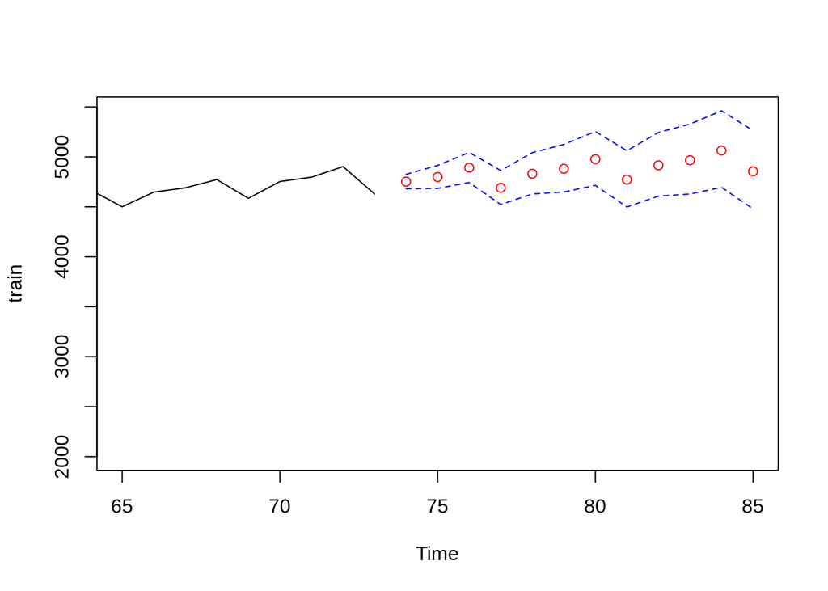

```r
ts.plot(train, xlim = c(65, length(train) + 12), ylim = c(2000, max(U)))
lines(U, col = "blue", lty = "dashed")
lines(L, col = "blue", lty = "dashed")
points((length(train) + 1):(length(train) + 12), pred.orig, col = "red")
```

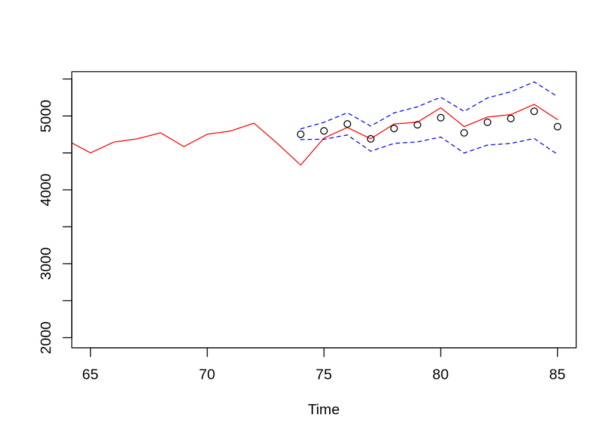

```r
ts.plot(gdp.csv, xlim = c(65, length(train) + 12), ylim = c(2000, max(U)), col = "red")
lines(U, col = "blue", lty = "dashed")
lines(L, col = "blue", lty = "dashed")
points((length(train) + 1):(length(train) + 12), pred.orig, col = "black")
```

We can see that the Test set is within prediction intervals except for the data point at April 2020 (pandemic).

Conclusion:

The results of the forecasting models revealed valuable insights into the behavior of U.S. real GDP over the studied period. The conclusions drawn from the project indicate that the selected models demonstrated effectiveness in capturing and predicting the dynamics of U.S. real GDP. The forecasts provided valuable information for decision-making, enabling policymakers, economists, and businesses to anticipate future economic trends and make informed decisions. The project contributes to a better understanding of the U.S. economy and provides insights into the factors driving U.S. real GDP growth.

Acknowledgments:

I would like to express my gratitude to Dr.Feldman for her guidance, support, and valuable insights throughout the project. Her expertise and feedback greatly enhanced the quality of the analysis and interpretation.

I would like to acknowledge the sources of the data used in this project, the U.S. Bureau of Economic Analysis (BEA) and the Federal Reserve Economic Data (FRED) database. Their comprehensive and reliable datasets served as the foundation for this analysis.